River A. Watson

## GLM-Poisson

**Conductivity levels as a predictor for Kentucky Arrow Darter abundance at a small spatial scale.**

**Conductivity levels measured ranged from 40us/cm to 285us/cm.**

**Catch per unit effort (CPUE) measured in fish caught per hour of shocking seconds.**

run poisson regression model

```r
cpue.data <- read.csv('Data/KAD_Cond_CPUE.csv')
cpue.glm <- glm(Conductivity ~ CPUE, data = cpue.data, family = poisson)
```

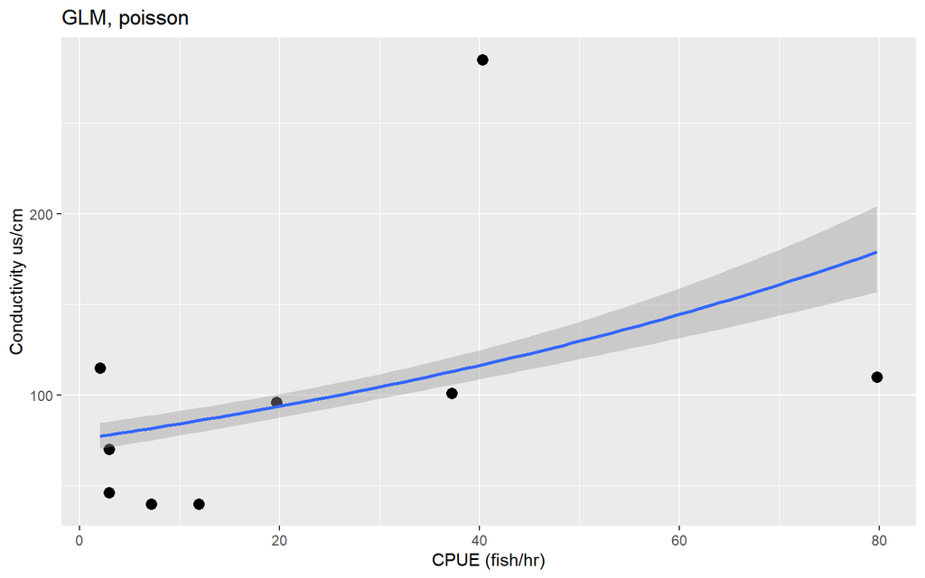

```r
ggplot(cpue.data, aes(CPUE, Conductivity)) +
  geom_point(size=3) +
  stat_smooth(method = glm, method.args = list(family = poisson(link = "log"))) +
  labs(title="GLM, poisson ") +
  xlab ("CPUE (fish/hr)") +
  ylab ("Conductivity us/cm")
```

Literally the opposite trend of what would be expected! (Future River plz explain to the people)

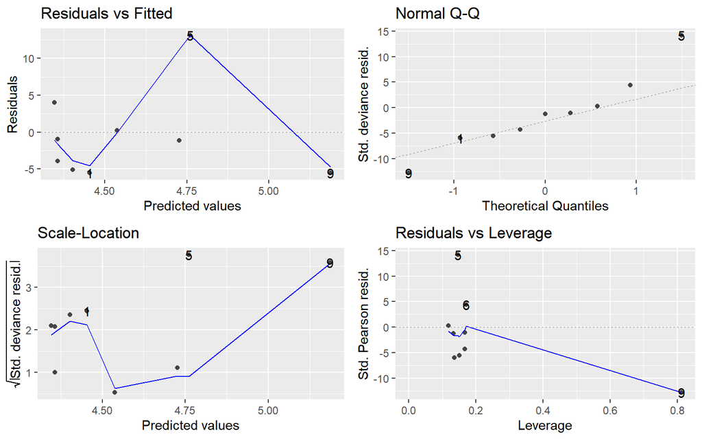

```r
autoplot(cpue.glm)
```

```r
anova(cpue.glm)
```

```
## Analysis of Deviance Table
##
## Model: poisson, link: log
##
## Response: Conductivity
##
## Terms added sequentially (first to last)
##
##
##      Df Deviance Resid. Df Resid. Dev
## NULL                     8     370.27
## CPUE  1   76.724         7     293.54
```

```r
summary(cpue.glm)
```

```
##
## Call:
## glm(formula = Conductivity ~ CPUE, family = poisson, data = cpue.data)
##
## Deviance Residuals:
##     Min       1Q   Median       3Q      Max
## -5.5489  -5.1206  -1.1434   0.2603  13.1195
##
## Coefficients:
##             Estimate Std. Error z value Pr(>|z|)
## (Intercept) 4.324678   0.048799  88.622   <2e-16 ***
## CPUE        0.010803   0.001182   9.142   <2e-16 ***
## ---
## Signif. codes:  0 '***' 0.001 '**' 0.01 '*' 0.05 '.' 0.1 ' ' 1
##
## (Dispersion parameter for poisson family taken to be 1)
##
##     Null deviance: 370.27  on 8  degrees of freedom
## Residual deviance: 293.54  on 7  degrees of freedom
## AIC: 353.84
##
## Number of Fisher Scoring iterations: 5
```

Data is greatly overdispersed-much more variable that expected

Run a quasi poisson regression to possibly get a better fit

```r
cpue.qglm <- glm(Conductivity ~ CPUE, quasipoisson, data = cpue.data)
summary(cpue.qglm)
```

```
##
## Call:
## glm(formula = Conductivity ~ CPUE, family = quasipoisson, data = cpue.data)
##
## Deviance Residuals:
##     Min       1Q   Median       3Q      Max
## -5.5489  -5.1206  -1.1434   0.2603  13.1195
##
## Coefficients:
##             Estimate Std. Error t value Pr(>|t|)
## (Intercept) 4.324678   0.344288  12.561 4.68e-06 ***
## CPUE        0.010803   0.008337   1.296    0.236
## ---
## Signif. codes:  0 '***' 0.001 '**' 0.01 '*' 0.05 '.' 0.1 ' ' 1
##
## (Dispersion parameter for quasipoisson family taken to be 49.77583)
##
##     Null deviance: 370.27  on 8  degrees of freedom
## Residual deviance: 293.54  on 7  degrees of freedom
## AIC: NA
##
## Number of Fisher Scoring iterations: 5
```

If our CPUE is 1 fish in one hour of shocking seconds what would the conductivity be?

```r
exp(4.324678+0.010803*1)
```

```
## [1] 76.36168
```

What if it was 30 fish/hr?

```r
exp(4.324678+0.010803*30)
```

```
## [1] 104.4562
```

What about 150 fish/hr?

```r
exp(4.324678+0.010803*150)
```

```
## [1] 381.8882
```

## GLM-Binomial Count

Data from an in progress species description, dont try to steal it or anything

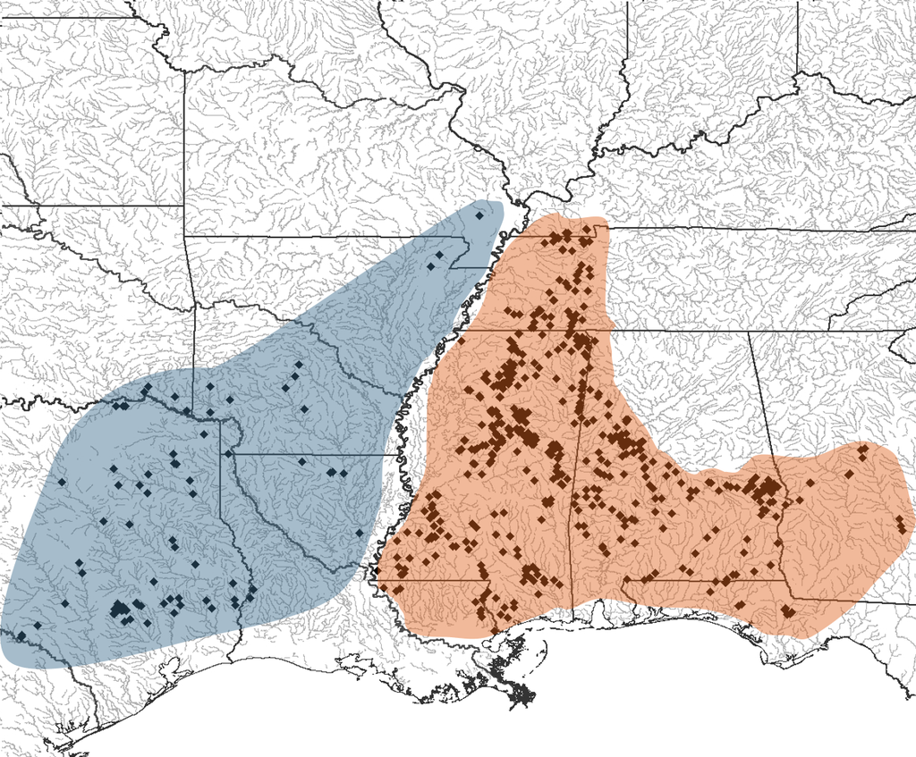

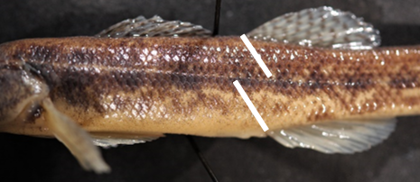

Figure 3. Transverse scales on an *Etheostoma parvipinne* specimen, counted following Hubbs and Lagler, 1958

```r
scale.data <- read.csv('data/Parvipinne_meristic_E_W_Trimmed.csv')
scale.glm <- glm(Group~Transverse_Total, data = scale.data, family = binomial)
```

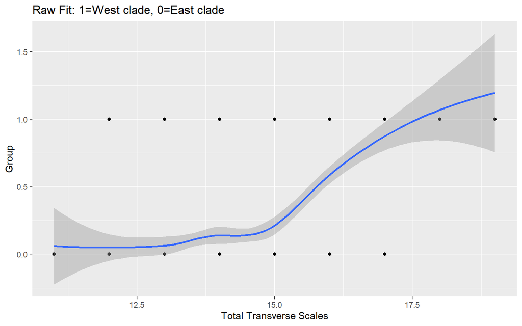

```r
ggplot(scale.data,aes(Transverse_Total,Group)) +
  geom_point() +
  geom_smooth() +
  xlab ("Total Transverse Scales") +
  ylab ("Group") +
  labs(title="Raw Fit: 1=West clade, 0=East clade")
```

0=East clade 1=West clade

Transverse scale counts are higher in the West clade and the East clade

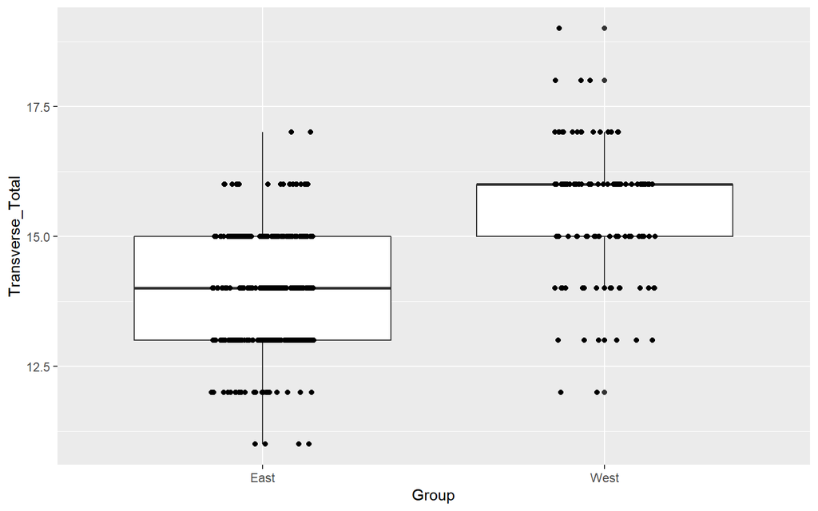

```r
scalegroup.data <- read.csv('data/Parvipinne_meristic_E_W.csv')

ggplot(scalegroup.data, aes(Group,Transverse_Total)) +
  geom_boxplot() +
  geom_jitter(height = 0, width = .15)
```

autoplot which really means nothing here

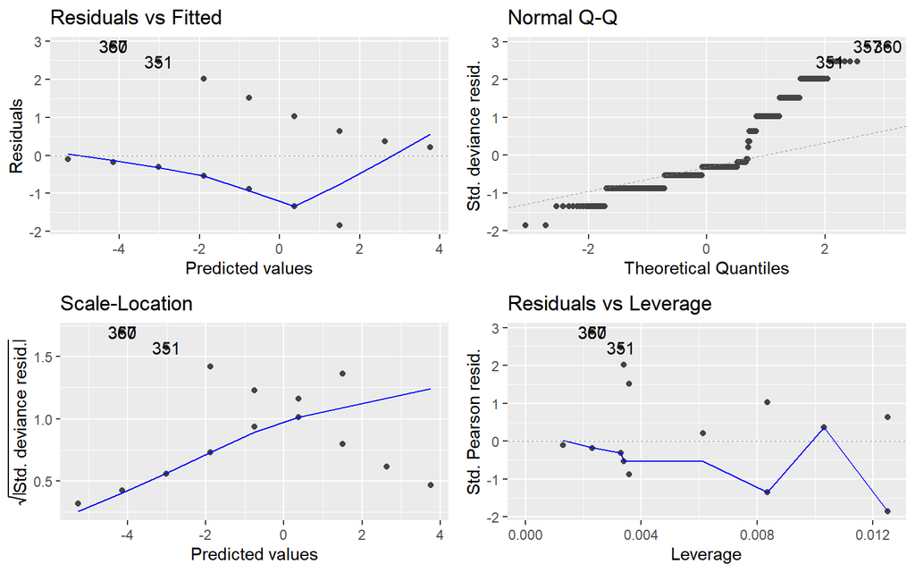

```r
autoplot(scale.glm)
```

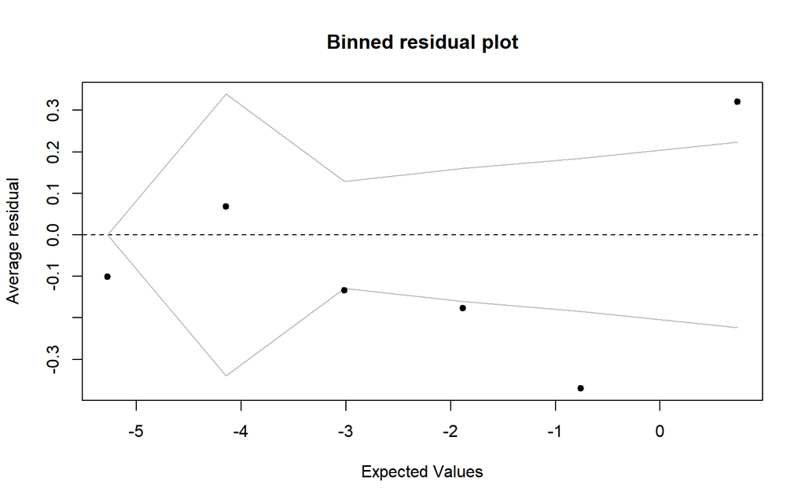

```r
x <- predict(scale.glm)
y <- resid(scale.glm)
binnedplot(x, y)
```

kinda looks like a sideways squid

```r
summary(scale.glm)
```

```
##
## Call:
## glm(formula = Group ~ Transverse_Total, family = binomial, data = scale.data)
##
## Deviance Residuals:
##     Min       1Q   Median       3Q      Max
## -1.8467  -0.5314  -0.3092  -0.1009   2.8853
##
## Coefficients:
##                  Estimate Std. Error z value Pr(>|z|)
## (Intercept)      -17.7100     1.8733  -9.454   <2e-16 ***
## Transverse_Total   1.1303     0.1253   9.023   <2e-16 ***
## ---
## Signif. codes:  0 '***' 0.001 '**' 0.01 '*' 0.05 '.' 0.1 ' ' 1
##
## (Dispersion parameter for binomial family taken to be 1)
##
##     Null deviance: 506.15  on 455  degrees of freedom
## Residual deviance: 381.71  on 454  degrees of freedom
## AIC: 385.71
##
## Number of Fisher Scoring iterations: 5
```

1.130268/4 = .282567, Transverse total scale count has a 28% chance of predicting which clade the individual is in

trying quasi binomial for a better fit

```r
scale.quasiglm <- glm(Group~Transverse_Total, data = scale.data, quasibinomial)
summary(scale.quasiglm)
```

```
##
## Call:
## glm(formula = Group ~ Transverse_Total, family = quasibinomial,
##     data = scale.data)
##
## Deviance Residuals:
##     Min       1Q   Median       3Q      Max
## -1.8467  -0.5314  -0.3092  -0.1009   2.8853
##
## Coefficients:
##                  Estimate Std. Error t value Pr(>|t|)
## (Intercept)      -17.7100     2.0869  -8.486 3.05e-16 ***
## Transverse_Total   1.1303     0.1395   8.100 5.13e-15 ***
## ---
## Signif. codes:  0 '***' 0.001 '**' 0.01 '*' 0.05 '.' 0.1 ' ' 1
##
## (Dispersion parameter for quasibinomial family taken to be 1.241055)
##
##     Null deviance: 506.15  on 455  degrees of freedom
## Residual deviance: 381.71  on 454  degrees of freedom
## AIC: NA
##
## Number of Fisher Scoring iterations: 5
```

Standard error increase

logit scale plot

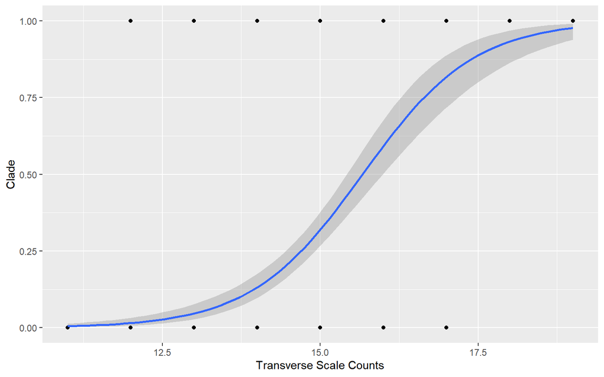

```r
ggplot(scale.data, aes(Transverse_Total,Group)) +
  geom_point() +
  geom_smooth(method="glm", method.args=list(family="binomial"(link="logit"))) +
  xlab ("Transverse Scale Counts") +
  ylab ("Clade")
```

0=East clade 1=West clade

The End

[output not shown]